# Reproducibility Report: Group B Choice 2

Shawn T. Schwartz

November 3, 2021

For this exercise, please try to reproduce the results from Experiment 1 of the associated paper (Ko, Sadler & Galinsky, 2015). The PDF of the paper is included in the same folder as this Rmd file.

#### Methods summary:

A sense of power has often been tied to how we perceive each other’s voice. Social hierarchy is embedded into the structure of society and provides a metric by which others relate to one another. In 1956, the Brunswik Lens Model was introduced to examine how vocal cues might influence hierarchy. In “The Sound of Power: Conveying and Detecting Hierarchical Rank Through Voice,” Ko and colleagues investigated how manipulation of hierarchical rank within a situation might impact vocal acoustic cues. Using the Brunswik Model, six acoustic metrics were utilized (pitch mean & variability, loudness mean & variability, and resonance mean & variability) to isolate a potential contribution between individuals of different hierarchal rank. In the first experiment, Ko, Sadler & Galinsky examined the vocal acoustic cues of individuals before and after being assigned a hierarchical rank in a sample of 161 subjects (80 male). Each of the six hierarchy acoustic cues were analyzed with a 2 (high vs. low rank condition) x 2 (male vs. female) analysis of covariance, controlling for the baseline of the respective acoustic cue.

#### Target outcomes:

Below is the specific result you will attempt to reproduce (quoted directly from the results section of Experiment 1):

> The impact of hierarchical rank on speakers’ acoustic cues. Each of the six hierarchy-based (i.e., postmanipulation) acoustic variables was submitted to a 2 (condition: high rank, low rank) × 2 (speaker’s sex: female, male) between-subjects analysis of covariance, controlling for the corresponding baseline acoustic variable. Table 4 presents the adjusted means by condition. Condition had a significant effect on pitch, pitch variability, and loudness variability. Speakers’ voices in the high-rank condition had higher pitch, **F(1, 156) = 4.48, p < .05**; were more variable in loudness, **F(1, 156) = 4.66, p < .05**; and were more monotone (i.e., less variable in pitch), **F(1, 156) = 4.73, p < .05**, compared with speakers’ voices in the low-rank condition (**all other Fs < 1**; see the Supplemental Material for additional analyses of covariance involving pitch and loudness). (from Ko et al., 2015, p. 6; emphasis added)

The adjusted means for these analyses are reported in Table 4 (Table4_AdjustedMeans.png, included in the same folder as this Rmd file).

## Step 1: Load packages

```r
library(tidyverse) # for data munging
library(knitr) # for kable table formating
library(haven) # import and export 'SPSS', 'Stata' and 'SAS' Files
library(readxl) # import excel files
library(car) # for ANCOVA
library(effectsize) # for calculating effect size
library(emmeans) # for estimating marginal means
```

## Step 2: Load data

```r
# Just Experiment 1
d <- read_csv("data/S1_voice_level_Final.csv")

## render data in markdown
DT::datatable(d)
```

|  | voice | form_smean | form_svar | form_rmean | form_rvar | intense_smean | intense_svar | intense_rmean | intense_rvar | pitch_smean | pitch_svar | pitch_rmean | pitch_rvar | pow | age | sex | race | native | feelpower | plev | vsex | pitch_rmeanMD | pitch_rvarMD | intense_rmeanMD | intense_rvarMD | formant_rmeanMD | formant_rvarMD | pitch_smeanMD | pitch_svarMD | … |
| --- | --- | --- | --- | --- | --- | --- | --- | --- | --- | --- | --- | --- | --- | --- | --- | --- | --- | --- | --- | --- | --- | --- | --- | --- | --- | --- | --- | --- | --- | --- |
| 1 | 1 | 1042.869962 | 38804.93761 | 1259.208907 | 68275.23613 | 65.49099021 | 157.3354322 | 58.70035143 | 174.0857333 | 116.027174 | 858.0678599 | 108.8287599 | 2481.725366 | 1 | 19 | M | X | Y | 6 | 1 | -1 | -40.74124011 | 729.2753665 | 1.240351433 | -8.664266701 | -33.40109257 | 4144.636134 | -41.05282602 | -679.5721401 | … |
| 2 | 2 | 1083.029813 | 35609.35816 | 1277.910104 | 54611.71739 | 65.47586904 | 300.9682296 | 63.89023073 | 271.3500336 | 145.6960287 | 1404.354463 | 133.1781929 | 1231.082125 | 3 | 21 | M | C | Y | 5 | 1 | -1 | -16.39180709 | -521.3678749 | 6.430230731 | 88.60003362 | -14.69989565 | -9518.882613 | -11.38397135 | -133.2855367 | … |
| 3 | 3 | 1092.225925 | 25978.96309 | 1333.830754 | 55175.29165 | 53.59891308 | 71.17353531 | 53.01939099 | 87.359022 | 105.5063343 | 706.219256 | 108.2639546 | 228.7220765 | 3 | 18 | M | A | Y | 3 | 1 | -1 | -41.30604541 | -1523.727924 | -4.440609009 | -95.390978 | 41.22075395 | -8955.308346 | -51.57366567 | -831.420744 | … |
| 4 | 4 | 1267.553623 | 71345.58644 | 1297.806593 | 74340.49653 | 60.70974876 | 201.1593872 | 59.75729362 | 198.7917441 | 102.1027965 | 449.8303663 | 107.596595 | 1744.493863 | 3 | 22 | M | C | Y | 6 | 1 | -1 | -41.973405 | -7.956136751 | 2.297293615 | 16.04174406 | 5.196593107 | 10209.89653 | -54.97720349 | -1087.809634 | … |
| 5 | 5 | 1071.457828 | 38245.57579 | 1255.766713 | 67846.20803 | 60.07251424 | 203.6822446 | 57.49530895 | 202.3901527 | 122.4731636 | 478.0700701 | 115.0597531 | 946.264262 | 4 | 20 | M | C | Y | 6 | 1 | -1 | -34.51024691 | -806.185738 | 0.035308954 | 19.64015271 | -36.84328731 | 3715.608029 | -34.60683641 | -1059.56993 | … |
| 6 | 6 | 1094.892145 | 40715.91723 | 1277.844136 | 76674.09743 | 60.0724431 | 150.4930403 | 58.36429566 | 149.6307961 | 137.1073832 | 622.8644356 | 126.8822931 | 420.3456699 | 1 | 21 | M | A | N | 4 | 1 | -1 | -22.68770687 | -1332.10433 | 0.904295661 | -33.11920386 | -14.76586439 | 12543.49743 | -19.97261683 | -914.7755644 | … |
| 7 | 7 | 1060.095415 | 38854.92309 | 1309.763798 | 88947.48454 | 60.54899645 | 126.9473748 | 57.86092888 | 180.5715687 | 106.3061345 | 313.2982175 | 114.7134307 | 2267.289555 | 2 | 18 | M | C | Y | 6 | 1 | -1 | -34.85656926 | 514.839555 | 0.400928882 | -2.178431334 | 17.15379796 | 24816.88454 | -50.77386546 | -1224.341783 | … |
| 8 | 8 | 1050.989236 | 28190.62536 | 1222.502296 | 52681.60884 | 57.25818276 | 206.6387985 | 57.31951186 | 195.6998271 | 104.6708708 | 1119.727445 | 101.0889908 | 2897.69537 | 1 | 18 | M | C | Y | 2 | -1 | -1 | -48.48100925 | 1145.24537 | -0.140488137 | 12.94982712 | -70.10770393 | -11448.99116 | -52.40912922 | -417.9125549 | … |
| 9 | 9 | 1037.920552 | 34105.08893 | 1255.951554 | 68508.02735 | 57.88633184 | 198.8997879 | 58.10657227 | 201.9492426 | 160.969481 | 444.0030139 | 161.7961392 | 696.5094919 | 1 | 23 | M | A | N | 5 | 1 | -1 | 12.2261392 | -1055.940508 | 0.646572269 | 19.19924259 | -36.65844624 | 4377.427347 | 3.889480959 | -1093.636986 | … |
| 10 | 10 | 1345.907783 | 69259.57495 | 1314.233802 | 55400.37537 | 60.27861517 | 148.7901098 | 58.44742658 | 157.7607398 | 131.65943 | 639.6703105 | 118.3914458 | 184.717257 | 1 | 19 | M | A | N | 3 | -1 | -1 | -31.17855422 | -1567.732743 | 0.987426584 | -24.98926018 | 21.62380201 | -8730.224634 | -25.42057004 | -897.9696895 | … |

[output cut: 151 more lines]

## Step 3: Tidy data

```r
## confirm participant counts reported in paper
nrow(d) == 161
```

```
## [1] TRUE
```

```r
nrow(subset(d, sex == "M")) == 80 ## male
```

```
## [1] TRUE
```

```r
nrow(subset(d, sex == "F")) == 81 ## female
```

```
## [1] TRUE
```

```r
## key variables from codebook:
### voice = voice identification number
### plev = hierarchy rank (+1 = high, -1 = low)
### vsex = speaker sex (+1 = female, -1 = male)
### ‘_s’ = script, acoustics recorded while saying negotiation script
### ‘_r’ = rainbow, acoustics recorded during rainbow passage
### ‘mean’ = average value of acoustic during a clip
### ‘var’ = variance for acoustic during a clip
### pitch = "pitch_..."
### loudness = "intense_..."
### resonance = "form_..."

### sort data by high/low-rank
d_high <- filter(d, plev == 1)
d_low <- filter(d, plev == -1)

## grab relevant columns
d_subset <- d |>
  select(voice, plev, vsex,
         starts_with("pitch"),
         starts_with("intense"),
         starts_with("form"))
```

## Step 4: Run analysis

### Pre-processing

```r
### create helper functions to facilitate analysis

get_model <- function(dv = c("pitch", "intense", "form"),
                      type = c("mean", "var"),
                      data = d_subset)
{
  ## dynamic function to build out model based on dv
  fit <- lm(formula = as.formula(
                        paste(paste0(dv, "_s", type), "~",
                        paste(paste0(dv, "_r", type), "+", "plev*vsex"))),
                      data = data)

  return(fit)
}

run_ancova <- function(fit)
{
  ## run ANCOVA
  ancova <- car::Anova(fit, type = "III")

  return(ancova)
}

get_adj_means <- function(fit,
                          dv = c("pitch", "intense", "form"),
                          type = c("mean", "var"),
                          data = d_subset)
{
  ## dynamically construct estimated marginal means formula based on dv
  estimated_means <- emmeans::emmeans(fit,
                                      paste0(dv, "_r", type),
                                      by = "plev",
                                      data = data)

  return(estimated_means)
}

get_es <- function(ancova)
{
  ## calculate effect size and suppress type 3 anova message that eta_squared returns
  ##  (to make the output pretty!)
  es <- suppressMessages(effectsize::eta_squared(ancova, partial = TRUE))
  es_rounded <- round(es$Eta2_partial[2], 2) ## round result to 2 significant figures to match paper's output in table 4

  return(es_rounded)
}

get_adj_means_by_rank <- function(adj_means, rank = c("low", "high"))
{
  if(rank == "low")
  {
    return(round(summary(adj_means)$emmean[1], 2))
  } else if(rank == "high")
  {
    return(round(summary(adj_means)$emmean[2], 2))
  } else {
    return(error("Invalid rank specified... please use 'low' or 'high' options!"))
  }
}

reconstruct_ancova_results <- function(ancova)
{
  df_1 <- ancova[3,2]
  df_2 <- ancova[6,2]
  F_stat <- ancova[3,3]
  p_stat <- ancova[3,4]

  results_string <- paste0("F(", df_1, ", ", df_2, ") = ", round(F_stat, 2), " p = ", round(p_stat, 3))

  return(results_string)
}
```

### Compute All Models

```r
## pitch mean
pitch_mean_model <- get_model("pitch", "mean")
pitch_mean_ancova <- run_ancova(pitch_mean_model)
pitch_mean_adjmeans <- get_adj_means(pitch_mean_model, "pitch", "mean")
pitch_mean_es <- get_es(pitch_mean_ancova)

## pitch variability
pitch_var_model <- get_model("pitch", "var")
pitch_var_ancova <- run_ancova(pitch_var_model)
pitch_var_adjmeans <- get_adj_means(pitch_var_model, "pitch", "var")
pitch_var_es <- get_es(pitch_var_ancova)

## loudness
loudness_mean_model <- get_model("intense", "mean")
loudness_mean_ancova <- run_ancova(loudness_mean_model)
loudness_mean_adjmeans <- get_adj_means(loudness_mean_model, "intense", "mean")
loudness_mean_es <- get_es(loudness_mean_ancova)

## loudness variability
loudness_var_model <- get_model("intense", "var")
loudness_var_ancova <- run_ancova(loudness_var_model)
loudness_var_adjmeans <- get_adj_means(loudness_var_model, "intense", "var")
loudness_var_es <- get_es(loudness_var_ancova)

## resonance
resonance_mean_model <- get_model("form", "mean")
resonance_mean_ancova <- run_ancova(resonance_mean_model)
resonance_mean_adjmeans <- get_adj_means(resonance_mean_model, "form", "mean")
resonance_mean_es <- get_es(resonance_mean_ancova)

## resonance variability
resonance_var_model <- get_model("form", "var")
resonance_var_ancova <- run_ancova(resonance_var_model)
resonance_var_adjmeans <- get_adj_means(resonance_var_model, "form", "var")
resonance_var_es <- get_es(resonance_var_ancova)
```

### Descriptive statistics

In the paper, the adjusted means by condition are reported (see Table 4, or Table4_AdjustedMeans.png, included in the same folder as this Rmd file). Reproduce these values below:

#### pitch mean

```r
## adjusted means (high-rank condition)
get_adj_means_by_rank(pitch_mean_adjmeans, "high")
```

```
## [1] 158.61
```

```r
## adjusted means (low-rank condition)
get_adj_means_by_rank(pitch_mean_adjmeans, "low")
```

```
## [1] 155.52
```

```r
## effect size
pitch_mean_es
```

```
## [1] 0.03
```

#### pitch variability

```r
## adjusted means (high-rank condition)
get_adj_means_by_rank(pitch_var_adjmeans, "high")
```

```
## [1] 1425.02
```

```r
## adjusted means (low-rank condition)
get_adj_means_by_rank(pitch_var_adjmeans, "low")
```

```
## [1] 1648.37
```

```r
## effect size
pitch_var_es
```

```
## [1] 0.03
```

#### loudness mean

```r
## adjusted means (high-rank condition)
get_adj_means_by_rank(loudness_mean_adjmeans, "high")
```

```
## [1] 59.34
```

```r
## adjusted means (low-rank condition)
get_adj_means_by_rank(loudness_mean_adjmeans, "low")
```

```
## [1] 58.67
```

```r
## effect size
loudness_mean_es
```

```
## [1] 0.01
```

#### loudness variability

```r
## adjusted means (high-rank condition)
get_adj_means_by_rank(loudness_var_adjmeans, "high")
```

```
## [1] 196.73
```

```r
## adjusted means (low-rank condition)
get_adj_means_by_rank(loudness_var_adjmeans, "low")
```

```
## [1] 183.48
```

```r
## effect size
loudness_var_es
```

```
## [1] 0.03
```

#### resonance mean

```r
## adjusted means (high-rank condition)
get_adj_means_by_rank(resonance_mean_adjmeans, "high")
```

```
## [1] 1129.38
```

```r
## adjusted means (low-rank condition)
get_adj_means_by_rank(resonance_mean_adjmeans, "low")
```

```
## [1] 1128.81
```

```r
## effect size
resonance_mean_es
```

```
## [1] 0
```

#### resonance variability

```r
## adjusted means (high-rank condition)
get_adj_means_by_rank(resonance_var_adjmeans, "high")
```

```
## [1] 42170.78
```

```r
## adjusted means (low-rank condition)
get_adj_means_by_rank(resonance_var_adjmeans, "low")
```

```
## [1] 43654.54
```

```r
## effect size
resonance_var_es
```

```
## [1] 0
```

#### Reconstruct Table 4

```r
Acoustic_cue <- c("Pitch", "Pitch Variability", "Loudness", "Loudness Variability",
                  "Resonance", "Resonance Variability")

High_rank_condition <- c(get_adj_means_by_rank(pitch_mean_adjmeans, "high"),
                         get_adj_means_by_rank(pitch_var_adjmeans, "high"),
                         get_adj_means_by_rank(loudness_mean_adjmeans, "high"),
                         get_adj_means_by_rank(loudness_var_adjmeans, "high"),
                         get_adj_means_by_rank(resonance_mean_adjmeans, "high"),
                         get_adj_means_by_rank(resonance_var_adjmeans, "high"))

Low_rank_condition <- c(get_adj_means_by_rank(pitch_mean_adjmeans, "low"),
                         get_adj_means_by_rank(pitch_var_adjmeans, "low"),
                         get_adj_means_by_rank(loudness_mean_adjmeans, "low"),
                         get_adj_means_by_rank(loudness_var_adjmeans, "low"),
                         get_adj_means_by_rank(resonance_mean_adjmeans, "low"),
                         get_adj_means_by_rank(resonance_var_adjmeans, "low"))

Effect_of_condition <- c(pitch_mean_es, pitch_var_es,
                         loudness_mean_es, loudness_var_es,
                         resonance_mean_es, resonance_var_es)

table4_reconstruction <- data.frame("Acoustic cue" = Acoustic_cue,
                                    "High-rank condition" = High_rank_condition,
                                    "Low-rank condition" = Low_rank_condition,
                                    "Effect of condition" = Effect_of_condition)

DT::datatable(table4_reconstruction)
```

|  | Acoustic.cue | High.rank.condition | Low.rank.condition | Effect.of.condition |
| --- | --- | --- | --- | --- |
| 1 | Pitch | 158.61 | 155.52 | 0.03 |
| 2 | Pitch Variability | 1425.02 | 1648.37 | 0.03 |
| 3 | Loudness | 59.34 | 58.67 | 0.01 |
| 4 | Loudness Variability | 196.73 | 183.48 | 0.03 |
| 5 | Resonance | 1129.38 | 1128.81 | 0 |
| 6 | Resonance Variability | 42170.78 | 43654.54 | 0 |

### Original Table 4 from paper

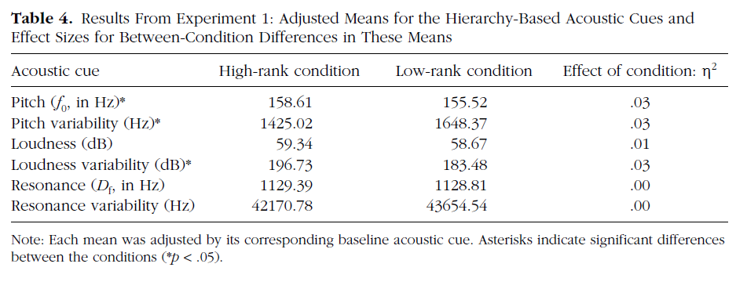

### Inferential statistics

> The impact of hierarchical rank on speakers’ acoustic cues. Each of the six hierarchy-based (i.e., postmanipulation) acoustic variables was submitted to a 2 (condition: high rank, low rank) × 2 (speaker’s sex: female, male) between-subjects analysis of covariance, controlling for the corresponding baseline acoustic variable. […] Condition had a significant effect on pitch, pitch variability, and loudness variability. Speakers’ voices in the high-rank condition had higher pitch, **F(1, 156) = 4.48, p < .05**; were more variable in loudness, **F(1, 156) = 4.66, p < .05**; and were more monotone (i.e., less variable in pitch), **F(1, 156) = 4.73, p < .05**, compared with speakers’ voices in the low-rank condition (**all other Fs < 1**; see the Supplemental Material for additional analyses of covariance involving pitch and loudness).

```r
# reproduce the above results here

## pitch mean
reconstruct_ancova_results(pitch_mean_ancova)
```

```
## [1] "F(1, 156) = 4.48 p = 0.036"
```

```r
## pitch variability
reconstruct_ancova_results(pitch_var_ancova)
```

```
## [1] "F(1, 156) = 4.73 p = 0.031"
```

```r
## loudness
reconstruct_ancova_results(loudness_mean_ancova)
```

```
## [1] "F(1, 156) = 2.21 p = 0.139"
```

```r
## loudness variability
reconstruct_ancova_results(loudness_var_ancova)
```

```
## [1] "F(1, 156) = 4.66 p = 0.032"
```

```r
## resonance
reconstruct_ancova_results(resonance_mean_ancova)
```

```
## [1] "F(1, 156) = 0 p = 0.965"
```

```r
## resonance variability
reconstruct_ancova_results(resonance_var_ancova)
```

```
## [1] "F(1, 156) = 0.47 p = 0.494"
```

## Step 5: Reflection

**How difficult was it to reproduce your results?**

Not very difficult; the only challenging component was figuring out which columns in the original dataset corresponded with the correct constructs being reported in the paper/the original figure. I also had to ensure that I knew which variables were the baseline and which weren’t to properly setup the models.

**What aspects made it difficult? What aspects made it easy?**

One of the most annoying issues I found was that in the original paper (Table 4), the authors reported eta-squared as the header for the table; however, the actual values that were computed were partial eta-squared effect sizes, which I caught when noticing initially that the numbers were off when I first computed full eta-squared effect sizes as I would have expected based on the header used in the table. Nonetheless, calculating partial eta-squared effect sizes resulted in the correct results reported in Table 4.